# Results of longitudinal BOLD delay manuscript

Ahmed Khalil

April 16, 2018

This is a comprehensive report of all the results of the “Longitudinal BOLD delay” manuscript, submitted to *JCBFM* in April 2018. Code written by Ahmed A Khalil (ahmed-abdelrahim.khalil@charite.de).

NB: These are all the results and plots *reported in the manuscript & supplementary material & uploaded to the online repository*.

NB: All effect sizes for the Wilcoxon signed-rank test (paired, i.e. two dependent groups) calculated according to *Rosenthal, Robert. Parametric measures of effect size. The handbook of research synthesis (1994): 231-244*.

# 1 Demographics & clinical characteristics

Table 1

| Patient no. | Age (years) | Sex | NIHSS - admission | NIHSS - discharge | Time from symptom onset to MRI (hours) | Occluded vessel | IV thrombolysis | Recanalization | TIMI score |
| --- | --- | --- | --- | --- | --- | --- | --- | --- | --- |
| 1 | 78 | M | 3 | 1 | 3.0 | P2 | YES | NO | 0 |
| 2 | 74 | F | 3 | 1 | 16.3 | A1 | NO | NO | 0 |
| 3 | 36 | M | 6 | 1 | 16.0 | M2 | YES | NO | 0 |
| 4 | 67 | M | 19 | 8 | 24.0 | M1 | NO | YES | 2 |
| 5 | 79 | F | 4 | 4 | 2.0 | M1 | YES | NO | 0 |
| 6 | 78 | M | 1 | 1 | 8.0 | M2 | NO | NO | 0 |
| 7 | 88 | M | 2 | 2 | 2.5 | P2 | YES | YES | 3 |
| 8 | 75 | F | 14 | 9 | 18.0 | M1 | NO | NO | 1 |
| 9 | 49 | F | 3 | 2 | 2.5 | P3 | YES | YES | 2 |
| 10 | 77 | M | 0 | 0 | 11.0 | P3 | NO | NO | 0 |
| 11 | 47 | M | 11 | 0 | 2.0 | M3 | YES | YES | 3 |
| 12 | 66 | M | 9 | 0 | 1.5 | M2 | YES | YES | 3 |
| 13 | 81 | F | 19 | 6 | 1.0 | M3 | YES | YES | 3 |
| 14 | 56 | M | 3 | 1 | 21.0 | M2 | NO | NO | 0 |
| 15 | 74 | M | 11 | 5 | 1.0 | P1 | YES | NO | 1 |

```
## [1] "Recanalizers"
```

```
##       Age        Sex     NIHSS_adm      NIHSS_dis       TOO_h
##  Min.   :47.00   F:2   Min.   : 2.0   Min.   :0.0   Min.   : 1.000
##  1st Qu.:53.25   M:4   1st Qu.: 4.5   1st Qu.:0.5   1st Qu.: 1.625
##  Median :66.50         Median :10.0   Median :2.0   Median : 2.250
##  Mean   :66.33         Mean   :10.5   Mean   :3.0   Mean   : 5.583
##  3rd Qu.:77.50         3rd Qu.:17.0   3rd Qu.:5.0   3rd Qu.: 2.500
##  Max.   :88.00         Max.   :19.0   Max.   :8.0   Max.   :24.000
##
##  Vessel Thrombolysis Recanalization      TIMI
##  A1:0   NO :1        NO :0          Min.   :2.000
##  M1:1   YES:5        YES:6          1st Qu.:2.250
##  M2:1                               Median :3.000
##  M3:2                               Mean   :2.667
##  P1:0                               3rd Qu.:3.000
##  P2:1                               Max.   :3.000
##  P3:1
```

```
## [1] "Non-recanalizers"
```

```
##       Age        Sex     NIHSS_adm    NIHSS_dis         TOO_h      Vessel
##  Min.   :36.00   F:3   Min.   : 0   Min.   :0.000   Min.   : 1.0   A1:1
##  1st Qu.:74.00   M:6   1st Qu.: 3   1st Qu.:1.000   1st Qu.: 3.0   M1:2
##  Median :75.00         Median : 3   Median :1.000   Median :11.0   M2:3
##  Mean   :69.67         Mean   : 5   Mean   :2.556   Mean   :10.7   M3:0
##  3rd Qu.:78.00         3rd Qu.: 6   3rd Qu.:4.000   3rd Qu.:16.3   P1:1
##  Max.   :79.00         Max.   :14   Max.   :9.000   Max.   :21.0   P2:1
##                                                                    P3:1
##  Thrombolysis Recanalization      TIMI
##  NO :5        NO :9          Min.   :0.0000
##  YES:4        YES:0          1st Qu.:0.0000
##                              Median :0.0000
##                              Mean   :0.2222
##                              3rd Qu.:0.0000
##                              Max.   :1.0000
##
```

# 2 Volumetric analysis

## 2.1 Figure 1 - Volume Boxplots with points overlain (manual delineation)

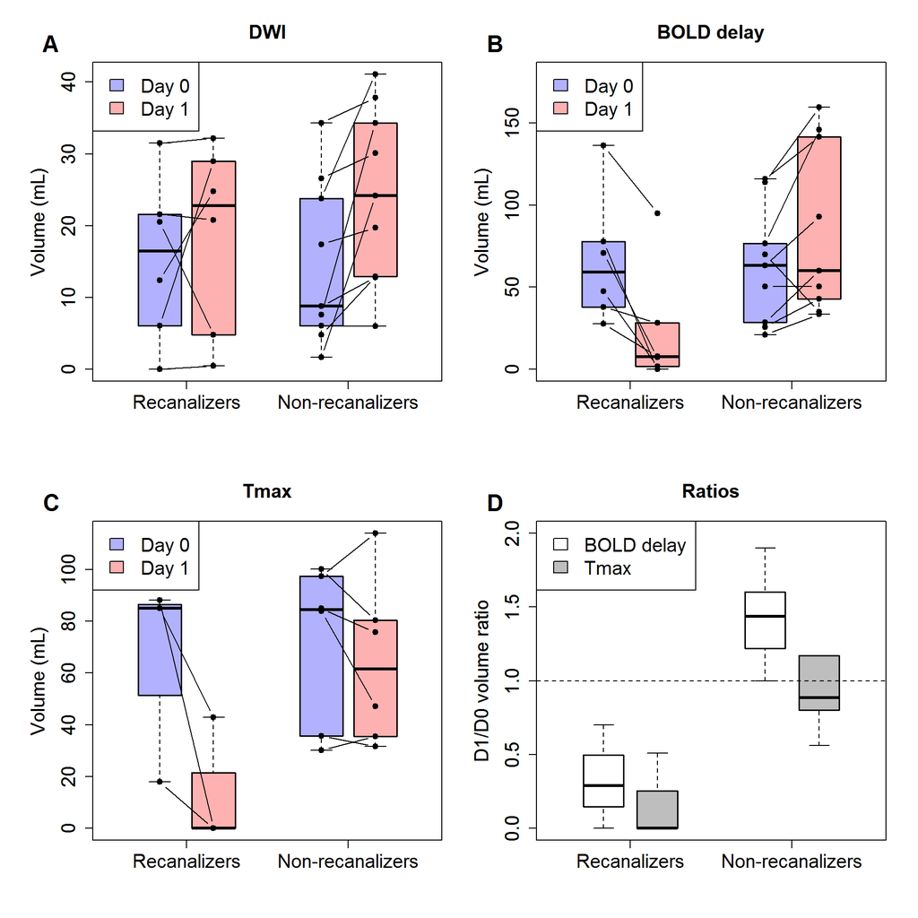

*Note that for the first 2 subfigures (A-B), ALL patients in the sample are included. For the last 2 subfigures (C-D), only patients who had both BD and Tmax are included.*

## 2.2 Supp Figure 1 - Volume Boxplots (automated delineation)

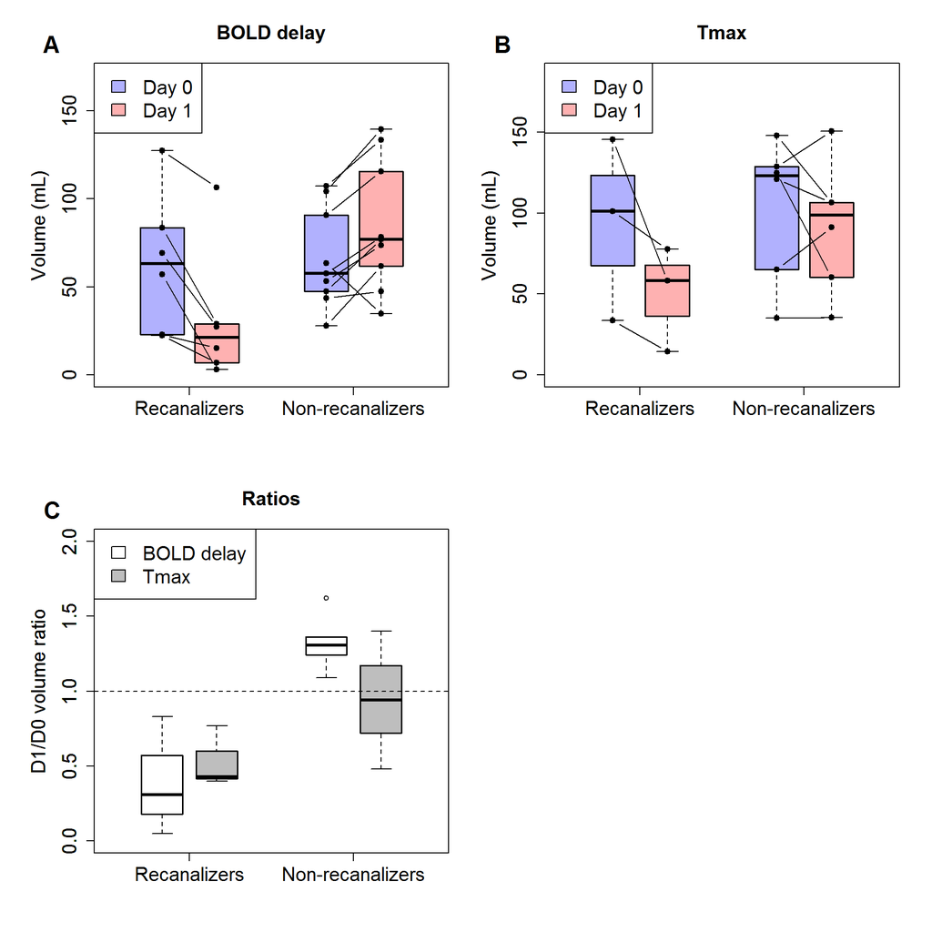

## 2.3 Lesion growth in recanalizers vs non-recanalizers

Difference between DWI lesion growth in recanalizers (median=1.02, IQR=0.96–2) vs non-recanalizers (median=1.46, IQR=1.13–2.71), p=0.3501179

Difference between BOLD delay lesion growth (manual) in recanalizers (median=0.195, IQR=0.055–0.5975) vs non-recanalizers (median=1.47, IQR=1.22–1.67), p=0.0015984

Difference between BOLD delay lesion growth (auto) in recanalizers (median=0.37, IQR=0.32–0.6) vs non-recanalizers (median=1.34, IQR=1.24–1.38), p=0.0015984

**In patients with vessel recanalization within 24 hours of baseline imaging, BOLD delay lesions become smaller. In patients with persistent vessel occlusion (PVO), BOLD delay lesions expand, unlike Tmax lesions, which tend to remain stable/shrink a little in this situation.**

## 2.4 Correlation between volume ratios and TIMI scores

Spearman’s rank correlation rho between BOLD delay volume ratio (manual) and TIMI score is -0.72, p = 0.00266.

Spearman’s rank correlation rho between BOLD delay volume ratio (auto) and TIMI score is -0.7, p = 0.00372.

**The change in BOLD delay lesion volume between baseline (D0) and follow-up (D1) correlates with the degree of vessel recanalization as measured by the TIMI score.**

## 2.5 Agreement between manually and automatically delineated perfusion lesion volumes

```
## [1] "BOLD delay ratios manual vs auto"
## [1] "ICC= 0.89 , 95% CI = 0.71 - 0.96 , p = 0 , F = 16.32"
## [1] "Tmax ratios manual vs auto"
## [1] "ICC= 0.7 , 95% CI = 0.18 - 0.92 , p = 0.0072 , F = 6.22"
```

# 3 Relationship between BOLD delay and Tmax - correlation and spatial overlap

```
## [1] "Descriptive stats for BD/Tmax Spearman's correlation (rho) - D0"
```

```
## [1] "All patients, Quantiles ="
```

```
##    0%   25%   50%   75%  100%
## 0.071 0.260 0.430 0.550 0.630
```

```
## [1] "rho_d0_recan Quantiles ="
##    0%   25%   50%   75%  100%
## 0.071 0.309 0.546 0.574 0.601
## [1] "rho_d0_nonrecan Quantiles ="
##    0%   25%   50%   75%  100%
## 0.086 0.276 0.376 0.505 0.634
```

```
## [1] "Descriptive stats for BD/Tmax spatial overlap (Dice coefficient) - D0"
```

```
##    Min. 1st Qu.  Median    Mean 3rd Qu.    Max.
##    0.28    0.44    0.58    0.53    0.63    0.73
```

# 4 Changes in perfusion (BOLD delay/Tmax) over time - group level

## 4.1 Figure 4 - Changes in mean Tmax and BOLD delay values within ROIs in the affected vascular territory

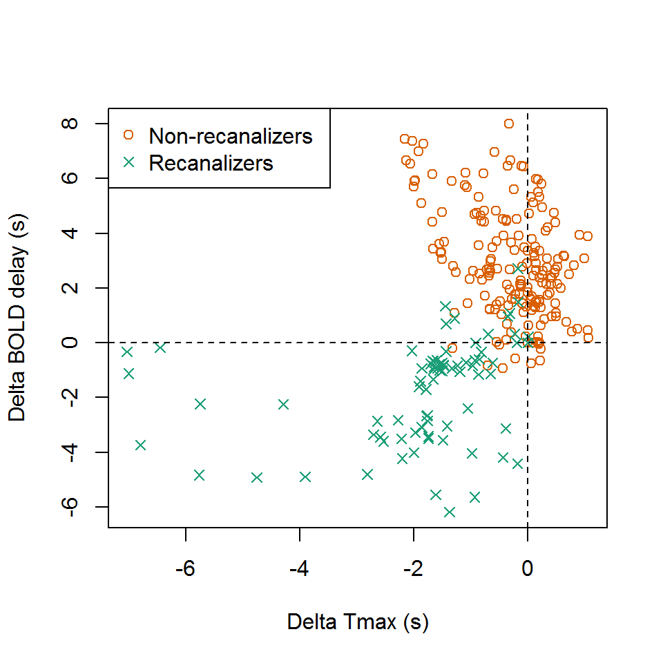

*Note that this is shown for ROIs within the affected VT and only patients who had both BD and Tmax are included.*

## 4.2 Figure 5 - voxelwise changes in BOLD delay and Tmax in subsample with both scans

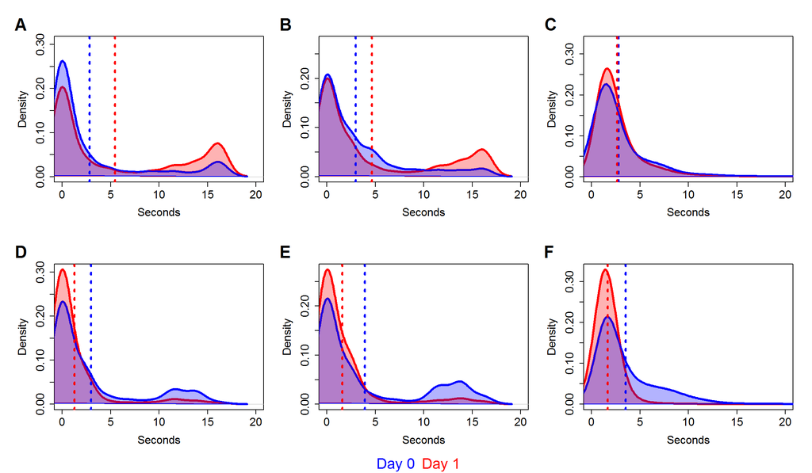

## 4.3 Supp Figure 3 - voxelwise changes in BOLD delay values in entire sample

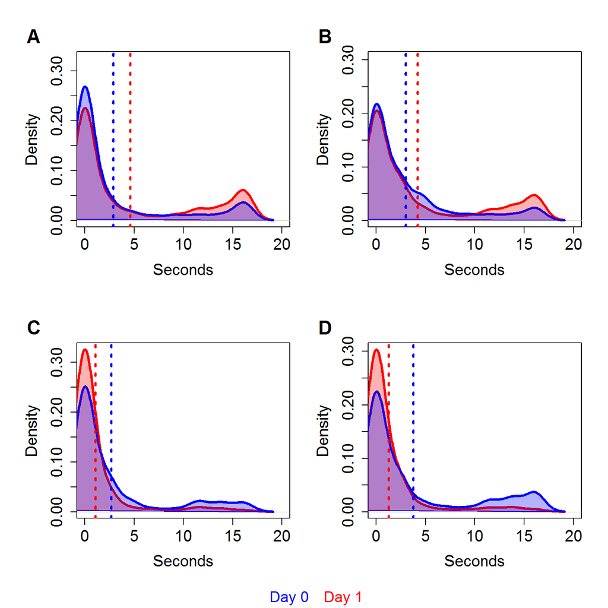

## 4.4 Figure 6 - Effect sizes for D0 vs D1 comparison in certain ROIs

```
## [1] "Non-recan TSA_VS_BL"
##     Min.  1st Qu.   Median     Mean  3rd Qu.     Max.
## -0.38350 -0.31090 -0.02741 -0.07208  0.13410  0.23050
## [1] "n= 9"
## [1] "Non-recan TSA_VS_D1IG"
##     Min.  1st Qu.   Median     Mean  3rd Qu.     Max.
## -0.46710 -0.39690 -0.36580 -0.27390 -0.19350  0.04155
## [1] "n= 9"
## [1] "Non-recan TSA_VS_VT"
##    Min. 1st Qu.  Median    Mean 3rd Qu.    Max.
## -0.3871 -0.3061 -0.2024 -0.1682 -0.1208  0.3683
## [1] "n= 9"
## [1] "Non-recan TSA_HH_BL"
##     Min.  1st Qu.   Median     Mean  3rd Qu.     Max.
## -0.51430 -0.46300 -0.10700 -0.12900  0.06324  0.28740
## [1] "n= 9"
## [1] "Non-recan TSA_HH_D1IG"
##     Min.  1st Qu.   Median     Mean  3rd Qu.     Max.
## -0.45670 -0.39150 -0.21710 -0.19280 -0.09809  0.17970
## [1] "n= 9"
## [1] "Non-recan TSA_HH_VT"
##     Min.  1st Qu.   Median     Mean  3rd Qu.     Max.
## -0.39840 -0.22580 -0.21080 -0.10750 -0.02068  0.35980
## [1] "n= 9"
```

```
## [1] "Recan TSA_VS_BL"
##    Min. 1st Qu.  Median    Mean 3rd Qu.    Max.
##  0.1838  0.3599  0.3927  0.3846  0.4792  0.5072
## [1] "n= 5"
## [1] "Recan TSA_VS_D1IG"
##    Min. 1st Qu.  Median    Mean 3rd Qu.    Max.
##  0.1094  0.2059  0.2652  0.3284  0.4678  0.6090
## [1] "n= 6"
## [1] "Recan TSA_VS_VT"
##    Min. 1st Qu.  Median    Mean 3rd Qu.    Max.
## -0.1144  0.2432  0.2781  0.2235  0.3190  0.3351
## [1] "n= 6"
## [1] "Recan TSA_HH_BL"
##    Min. 1st Qu.  Median    Mean 3rd Qu.    Max.
##  0.1816  0.2149  0.4449  0.3796  0.4689  0.5875
## [1] "n= 5"
## [1] "Recan TSA_HH_D1IG"
##    Min. 1st Qu.  Median    Mean 3rd Qu.    Max.
## -0.3071  0.3287  0.4055  0.3061  0.4507  0.5636
## [1] "n= 6"
## [1] "Recan TSA_HH_VT"
##    Min. 1st Qu.  Median    Mean 3rd Qu.    Max.
## -0.1031  0.2339  0.2691  0.2534  0.3754  0.4524
## [1] "n= 6"
```

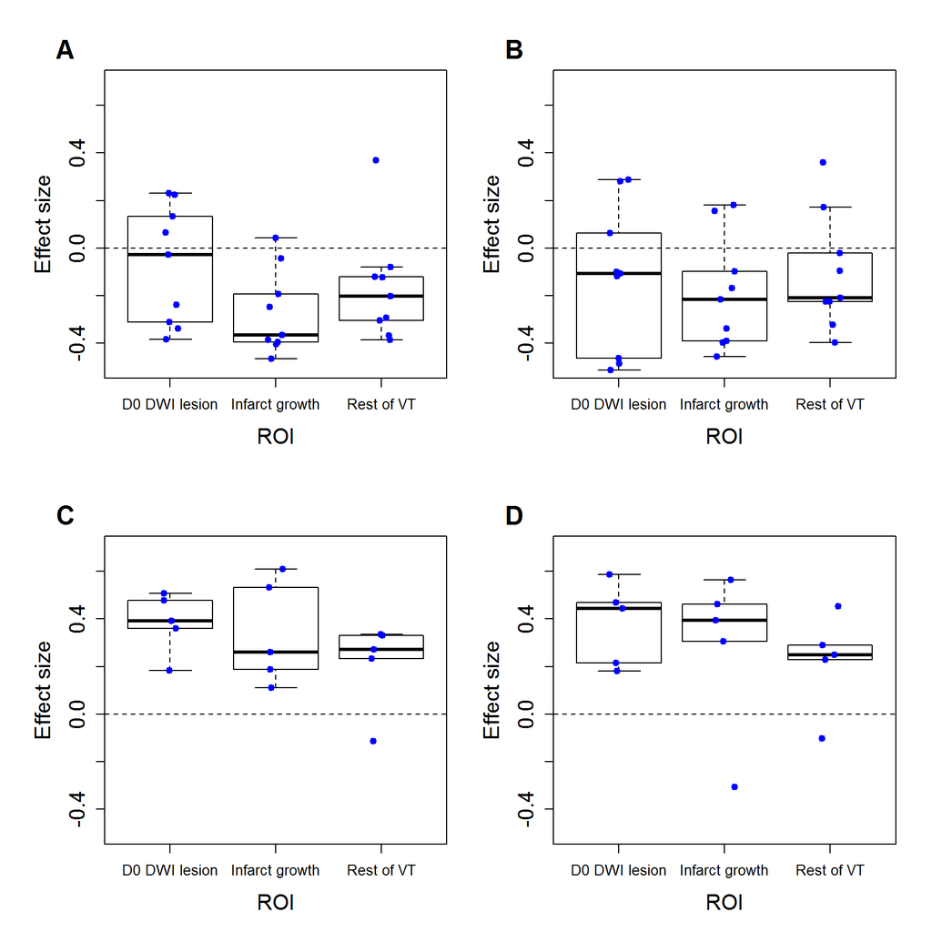

## 4.5 Supp Figure 6 - Distribution of maximum correlation coefficients in ROIs, pooled across all subjects

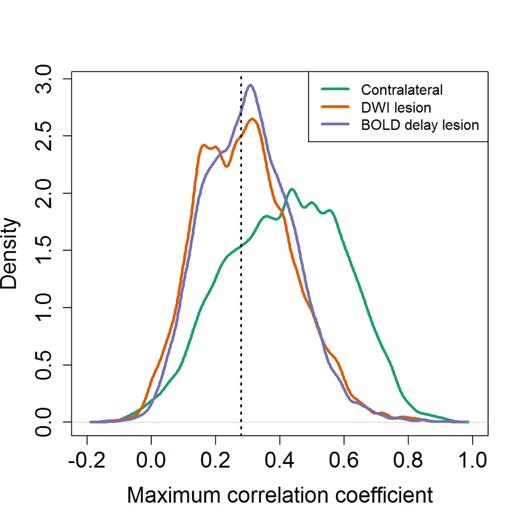

*Note that, in this analysis, n=14 because one subject (sub0179) had a total mismatch at baseline.*

# 5 Changes in perfusion (BOLD delay/Tmax) over time - individual level

These results are not in the manuscript, they are on a publicly accessible repository: https://doi.org/10.6084/m9.figshare.5904619

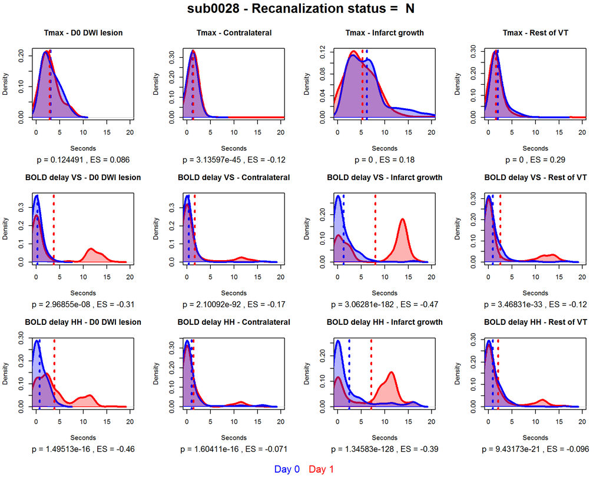

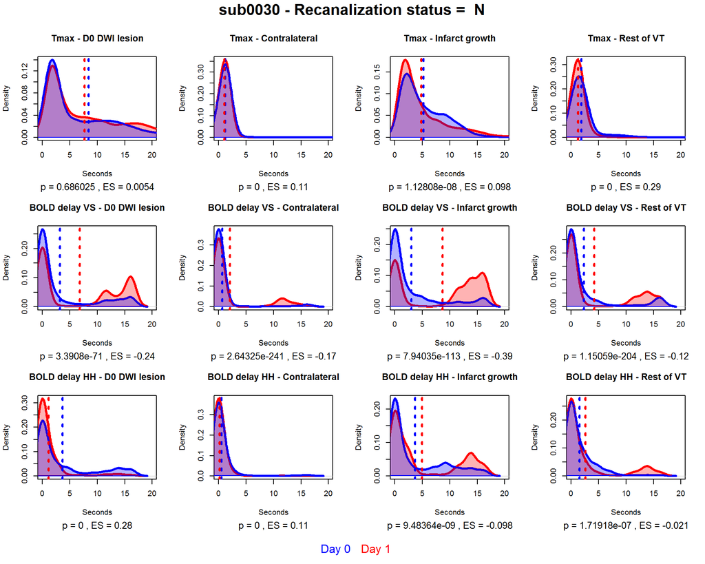

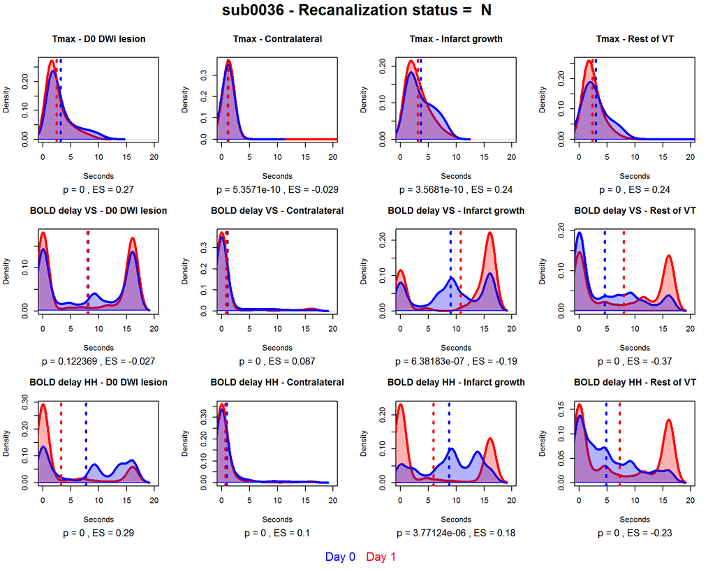

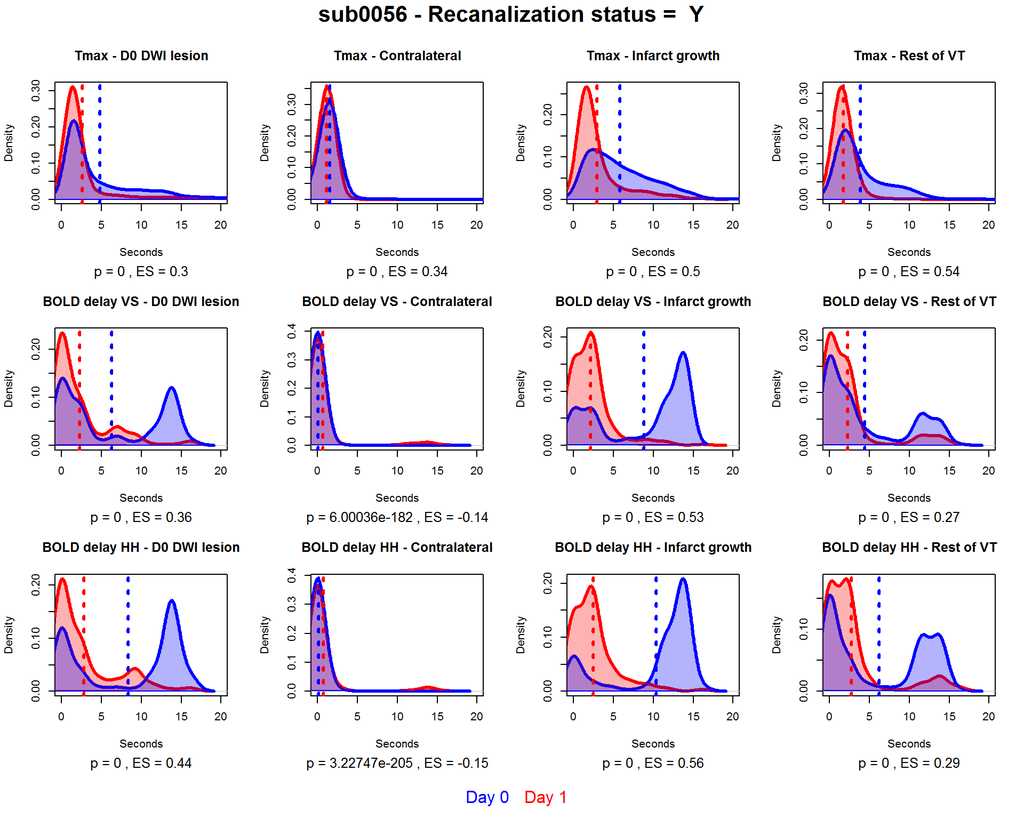

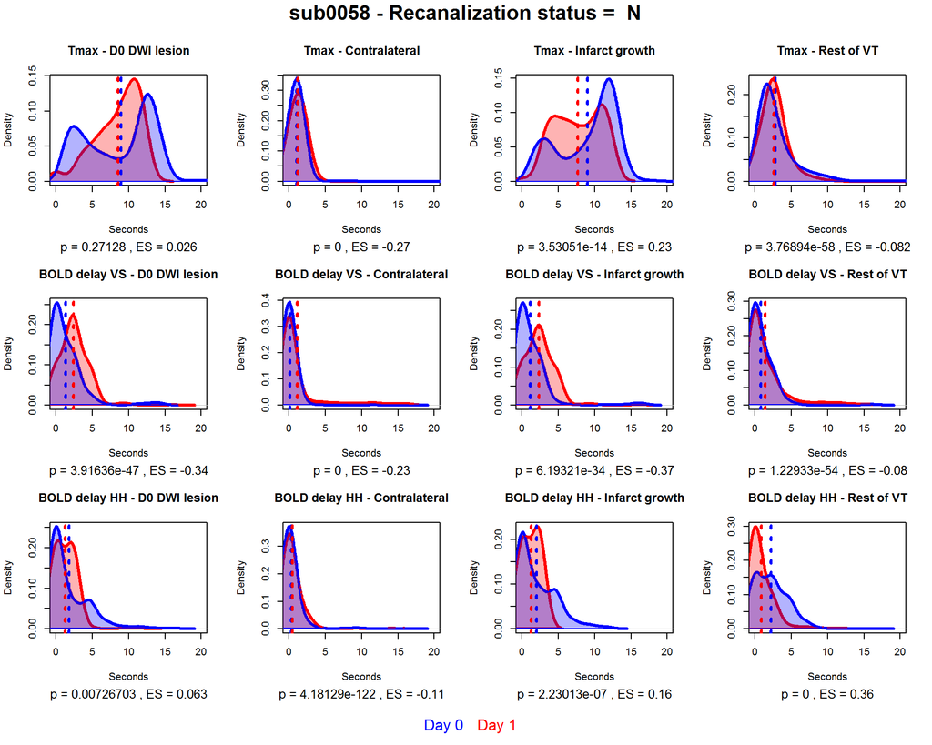

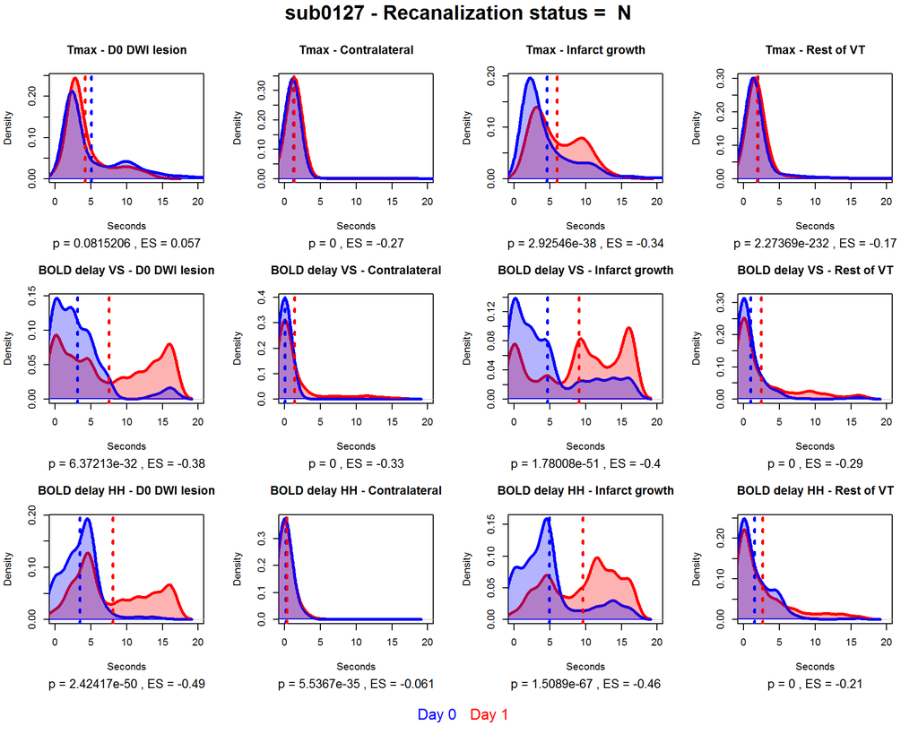

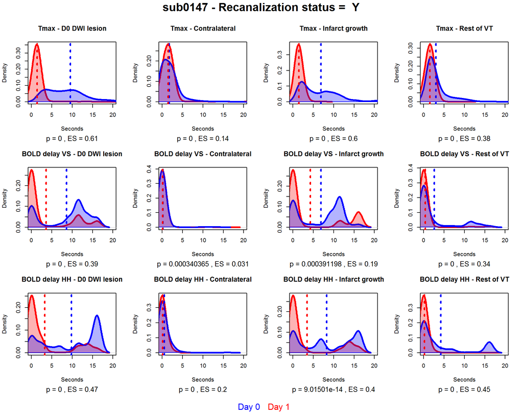

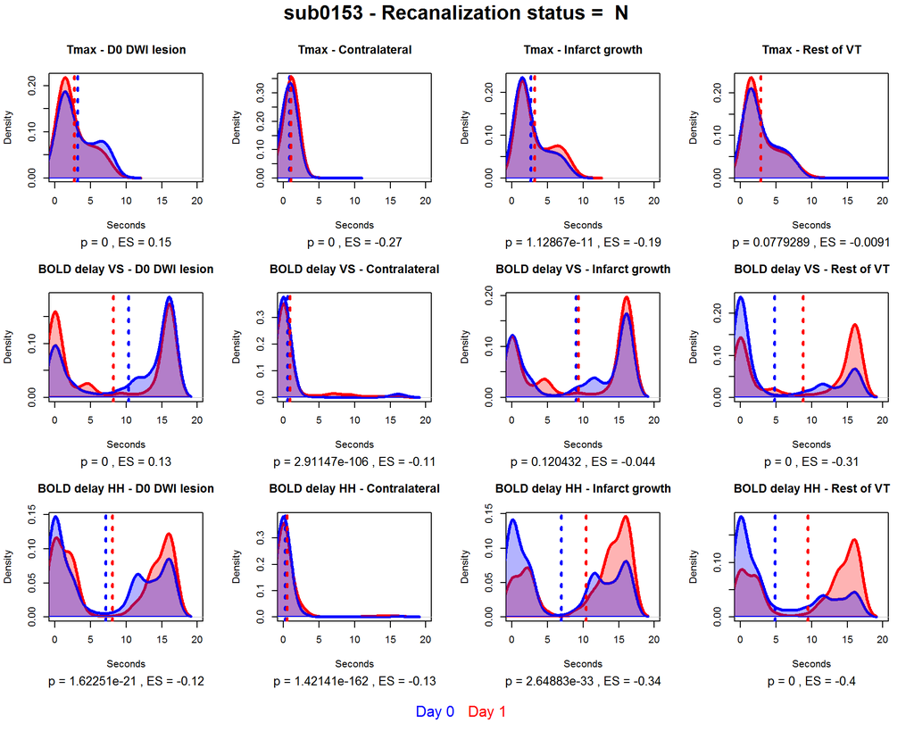

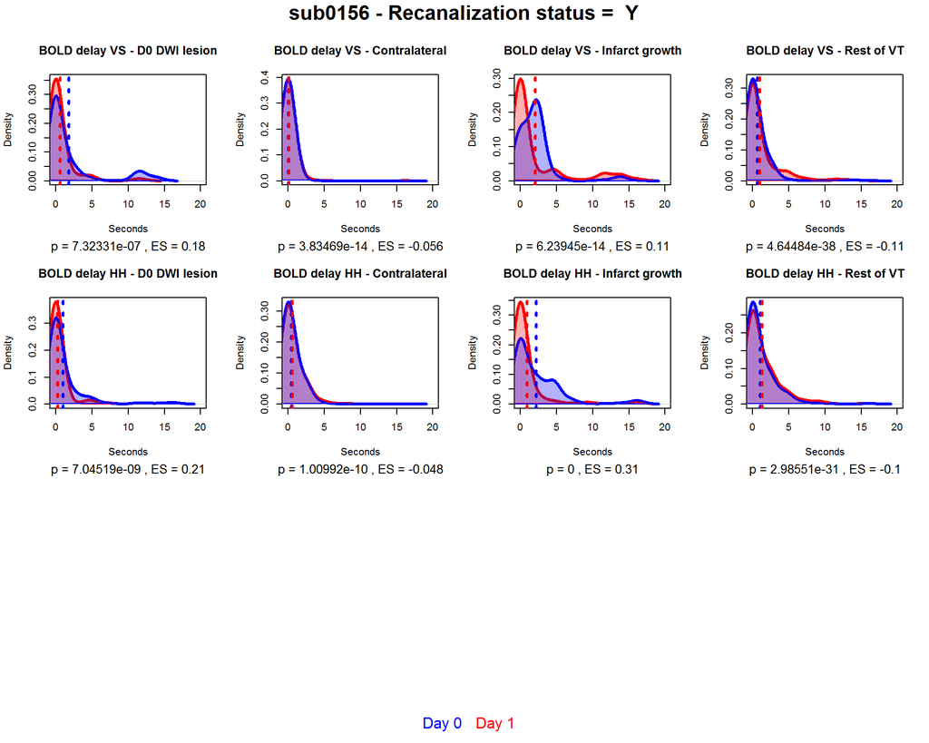

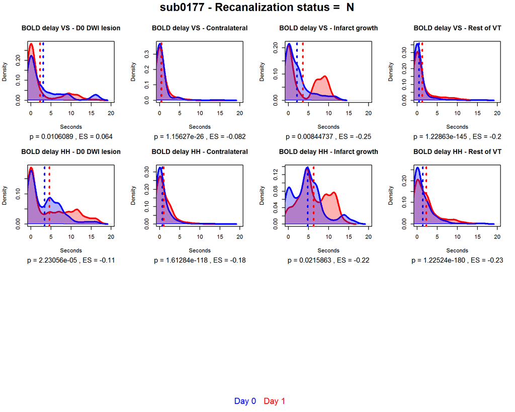

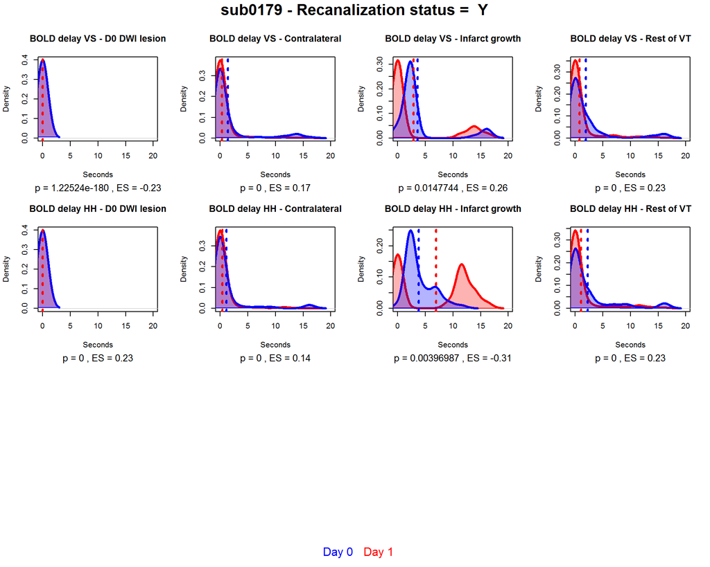

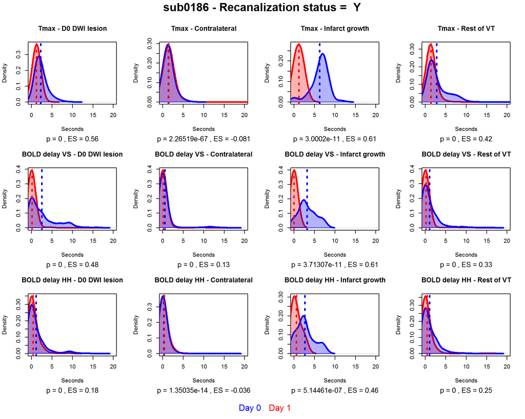

[3 more figures not shown]